# HW8

Caroline Dumas

March 31, 2021

To start simply, assume that the data in each of your treatment groups follow a normal distribution. Specify the sample sizes, means, and variances for each group that would be reasonable if your hypothesis were true. You may need to consult some previous literature and/or an expert in the field to come up with these numbers.

**I have a dataset with 4 treatment groups (WT, Sema6A MO, FL rescue, DeltaC rescue) (independent variable) and a continuous variable of number pHH3 positive cells per eye field (dependent variable). Based on my data, I would expect the mean of the WT group to be 36, the mean of the Sema6A MO group to be 13, the mean of the FL rescue group and the DeltaC rescue group to be 26. I will assume the standard deviation to be 5 and equal between all of the groups. I expect a sample size of 20 to detect significance between the groups**

Using the methods we have covered in class, write code to create a random data set that has these attributes. Organize these data into a data frame with the appropriate structure.

```r
set.seed(99)
WT <- rnorm(n=20, mean=36, sd=5)
head(WT)
```

```
## [1] 37.06981 38.39829 36.43914 38.21929 34.18581 36.61337
```

```r
sema6aMO <- rnorm(n=20, mean=13, sd=5)
head(sema6aMO)
```

```
## [1] 18.49461 16.76257 12.70292 11.27716 14.11334 15.75893
```

```r
FLrescue <- rnorm(n=20, mean=26, sd=5)
head(FLrescue)
```

```
## [1] 26.66489 17.60368 24.60760 18.23795 19.10150 19.21472
```

```r
deltaCrescue <- rnorm(n=20, mean=26, sd=5)
head(deltaCrescue)
```

```
## [1] 25.18541 25.42892 23.77670 27.28480 20.49931 19.31712
```

```r
pHH3DataFrame <- data.frame(WT, sema6aMO,
                            FLrescue, deltaCrescue)
str(pHH3DataFrame)
```

```
## 'data.frame':    20 obs. of  4 variables:
##  $ WT          : num  37.1 38.4 36.4 38.2 34.2 ...
##  $ sema6aMO    : num  18.5 16.8 12.7 11.3 14.1 ...
##  $ FLrescue    : num  26.7 17.6 24.6 18.2 19.1 ...
##  $ deltaCrescue: num  25.2 25.4 23.8 27.3 20.5 ...
```

```r
head(pHH3DataFrame)
```

```
##         WT sema6aMO FLrescue deltaCrescue
## 1 37.06981 18.49461 26.66489     25.18541
## 2 38.39829 16.76257 17.60368     25.42892
## 3 36.43914 12.70292 24.60760     23.77670
## 4 38.21929 11.27716 18.23795     27.28480
## 5 34.18581 14.11334 19.10150     20.49931
## 6 36.61337 15.75893 19.21472     19.31712
```

```r
# This set up won't work for the ANOVA because we need the treatment groups in a column and the pHH3 count in the next column
library(tidyr)
pHH3model <- gather(pHH3DataFrame, Treatment,
                    pHH3_count, WT:deltaCrescue)
print(pHH3model)
```

```
##       Treatment pHH3_count
## 1            WT  37.069813
## 2            WT  38.398291
## 3            WT  36.439144
## 4            WT  38.219293
## 5            WT  34.185810
## 6            WT  36.613370
## 7            WT  31.680774
## 8            WT  38.448121
## 9            WT  34.179415
## 10           WT  29.528790
## 11           WT  32.271155
## 12           WT  40.607752
## 13           WT  39.750272
## 14           WT  23.457230
```

[output cut: 66 more lines]

Now write code to analyze the data (probably as an ANOVA or regression analysis, but possibly as a logistic regression or contingency table analysis. Write code to generate a useful graph of the data.

```r
pHH3model_ano <- aov(pHH3_count ~ Treatment, data=pHH3model)
print(pHH3model_ano)
```

```
## Call:
##    aov(formula = pHH3_count ~ Treatment, data = pHH3model)
##
## Terms:
##                 Treatment Residuals
## Sum of Squares   4491.182  1521.128
## Deg. of Freedom         3        76
##
## Residual standard error: 4.473795
## Estimated effects may be unbalanced
```

```r
summary(pHH3model_ano)
```

```
##             Df Sum Sq Mean Sq F value Pr(>F)
## Treatment    3   4491    1497    74.8 <2e-16 ***
## Residuals   76   1521      20
## ---
## Signif. codes:  0 '***' 0.001 '**' 0.01 '*' 0.05 '.' 0.1 ' ' 1
```

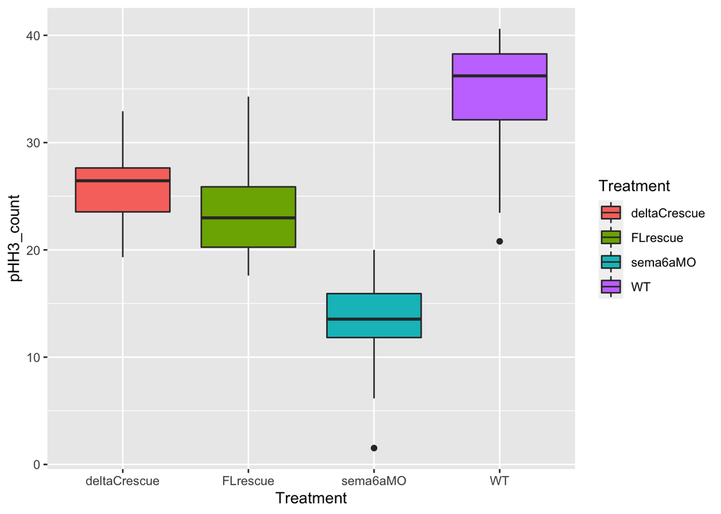

```r
# There is significance

# generate a box plot for this
library(ggplot2)
ano_plot <- ggplot(data=pHH3model,
                            aes(x=Treatment,
                                y=pHH3_count,
                                fill=Treatment)) +
                            geom_boxplot()
print(ano_plot)
```

Try running your analysis multiple times to get a feeling for how variable the results are with the same parameters, but different sets of random numbers.

```r
set.seed(10)
WT <- rnorm(n=20, mean=36, sd=5)
sema6aMO <- rnorm(n=20, mean=13, sd=5)
FLrescue <- rnorm(n=20, mean=26, sd=5)
deltaCrescue <- rnorm(n=20, mean=26, sd=5)
pHH3DataFrame <- data.frame(WT, sema6aMO,
                            FLrescue, deltaCrescue)
library(tidyr)
pHH3model <- gather(pHH3DataFrame, Treatment,
                    pHH3_count, WT:deltaCrescue)
pHH3model_ano <- aov(pHH3_count ~ Treatment, data=pHH3model)
print(pHH3model_ano)
```

```
## Call:
##    aov(formula = pHH3_count ~ Treatment, data = pHH3model)
##
## Terms:
##                 Treatment Residuals
## Sum of Squares   7257.050  1488.998
## Deg. of Freedom         3        76
##
## Residual standard error: 4.426294
## Estimated effects may be unbalanced
```

```r
summary(pHH3model_ano)
```

```
##             Df Sum Sq Mean Sq F value Pr(>F)
## Treatment    3   7257  2419.0   123.5 <2e-16 ***
## Residuals   76   1489    19.6
## ---
## Signif. codes:  0 '***' 0.001 '**' 0.01 '*' 0.05 '.' 0.1 ' ' 1
```

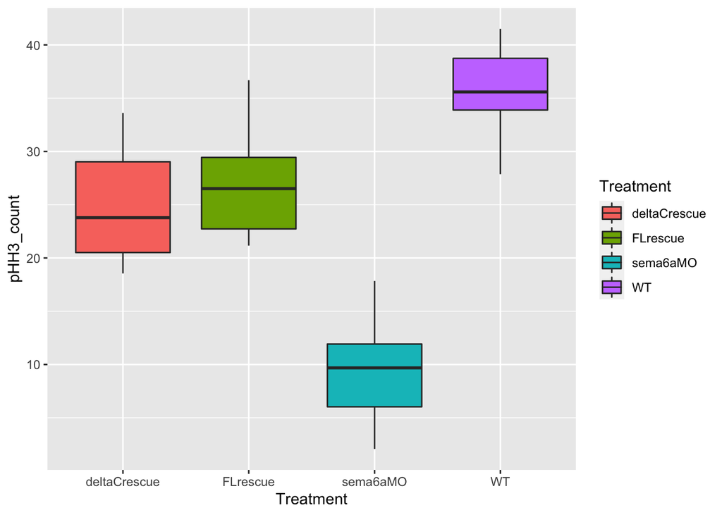

```r
# There is significance

# generate a box plot for this
library(ggplot2)
ano_plot <- ggplot(data=pHH3model,
                            aes(x=Treatment,
                                y=pHH3_count,
                                fill=Treatment)) +
                            geom_boxplot()
print(ano_plot)
```

Now begin adjusting the means of the different groups. Given the sample sizes you have chosen, how small can the differences between the groups be (the “effect size”) for you to still detect a significant pattern (p < 0.05)?

```r
# for this data set there are 3 groups that are different so I am going to change them all the same way to see when the significance goes away.
set.seed(20)
WT <- rnorm(n=20, mean=36, sd=5)
sema6aMO <- rnorm(n=20, mean=31, sd=5)
FLrescue <- rnorm(n=20, mean=31, sd=5)
deltaCrescue <- rnorm(n=20, mean=31, sd=5)
pHH3DataFrame <- data.frame(WT, sema6aMO,
                            FLrescue, deltaCrescue)
library(tidyr)
pHH3model <- gather(pHH3DataFrame, Treatment,
                    pHH3_count, WT:deltaCrescue)
pHH3model_ano <- aov(pHH3_count ~ Treatment, data=pHH3model)
print(pHH3model_ano)
```

```
## Call:
##    aov(formula = pHH3_count ~ Treatment, data = pHH3model)
##
## Terms:
##                 Treatment Residuals
## Sum of Squares   304.5993 1870.1367
## Deg. of Freedom         3        76
##
## Residual standard error: 4.960551
## Estimated effects may be unbalanced
```

```r
summary(pHH3model_ano)
```

```
##             Df Sum Sq Mean Sq F value  Pr(>F)
## Treatment    3  304.6  101.53   4.126 0.00913 **
## Residuals   76 1870.1   24.61
## ---
## Signif. codes:  0 '***' 0.001 '**' 0.01 '*' 0.05 '.' 0.1 ' ' 1
```

Alternatively, for the effect sizes you originally hypothesized, what is the minimum sample size you would need in order to detect a statistically significant effect? Again, run the model a few times with the same parameter set to get a feeling for the effect of random variation in the data.

```r
# going back to the original mean numbers and changing the n value for all of them
set.seed(30)
WT <- rnorm(n=3, mean=36, sd=5)
sema6aMO <- rnorm(n=3, mean=13, sd=5)
FLrescue <- rnorm(n=3, mean=26, sd=5)
deltaCrescue <- rnorm(n=3, mean=26, sd=5)
pHH3DataFrame <- data.frame(WT, sema6aMO,
                            FLrescue, deltaCrescue)
library(tidyr)
pHH3model <- gather(pHH3DataFrame, Treatment,
                    pHH3_count, WT:deltaCrescue)
pHH3model_ano <- aov(pHH3_count ~ Treatment, data=pHH3model)
print(pHH3model_ano)
```

```
## Call:
##    aov(formula = pHH3_count ~ Treatment, data = pHH3model)
##
## Terms:
##                 Treatment Residuals
## Sum of Squares   432.5874  239.7415
## Deg. of Freedom         3         8
##
## Residual standard error: 5.474275
## Estimated effects may be unbalanced
```

```r
summary(pHH3model_ano)
```

```
##             Df Sum Sq Mean Sq F value Pr(>F)
## Treatment    3  432.6  144.20   4.812 0.0336 *
## Residuals    8  239.7   29.97
## ---
## Signif. codes:  0 '***' 0.001 '**' 0.01 '*' 0.05 '.' 0.1 ' ' 1
```

**A little bit crazy, but only having an n of 3 still allows for significance between the groups.**